# Statistical Inference ToothGrowth Data Part 2

Jatin chawda

2/25/2020

#The project consists of two parts: #1. Simulation Exercise to explore inferenced #2. Basic inferential analysis using the ToothGrowth data in the R datasets package

## Part 2 Statistical Inference using ToothGrowth Dataset Part

# Overview

Analyze the ToothGrowth data in the R datasets package.

What We have to do

1. Load the ToothGrowth data and perform some basic exploratory data analysis
2. Provide a basic summary of the data
3. Use confidence intervals and/or hypothesis tests to compare tooth growth by supp and dose
4. State your conclusions and the assumptions needed for your conclusions

# Load Libraries

```r
library(data.table)
```

```r
library(ggplot2)
library(datasets)
```

# Load the ToothGrowth dataset

```r
toothGrowth <- data.table(ToothGrowth)
```

## Description of Dataset

The response is the length of odontoblasts (cells responsible for tooth growth) in 60 guinea pigs. Each animal received one of three dose levels of vitamin C (0.5, 1, and 2 mg/day) by one of two delivery methods, (orange juice or ascorbic acid (a form of vitamin C and coded as VC).

## Format Of dataset

A data frame with 60 observations on 3 variables.

# Exploratory Data Analysis

```r
head(toothGrowth)
```

```
##     len supp dose
## 1:  4.2   VC  0.5
## 2: 11.5   VC  0.5
## 3:  7.3   VC  0.5
## 4:  5.8   VC  0.5
## 5:  6.4   VC  0.5
## 6: 10.0   VC  0.5
```

```r
tail(toothGrowth)
```

```
##     len supp dose
## 1: 24.8   OJ    2
## 2: 30.9   OJ    2
## 3: 26.4   OJ    2
## 4: 27.3   OJ    2
## 5: 29.4   OJ    2
## 6: 23.0   OJ    2
```

The three variables are length, supplement, and dose.

```r
summary(ToothGrowth)
```

```
##       len        supp         dose
##  Min.   : 4.20   OJ:30   Min.   :0.500
##  1st Qu.:13.07   VC:30   1st Qu.:0.500
##  Median :19.25           Median :1.000
##  Mean   :18.81           Mean   :1.167
##  3rd Qu.:25.27           3rd Qu.:2.000
##  Max.   :33.90           Max.   :2.000
```

```r
str(ToothGrowth)
```

```
## 'data.frame':    60 obs. of  3 variables:
##  $ len : num  4.2 11.5 7.3 5.8 6.4 10 11.2 11.2 5.2 7 ...
##  $ supp: Factor w/ 2 levels "OJ","VC": 2 2 2 2 2 2 2 2 2 2 ...
##  $ dose: num  0.5 0.5 0.5 0.5 0.5 0.5 0.5 0.5 0.5 0.5 ...
```

```r
unique(ToothGrowth$dose)
```

```
## [1] 0.5 1.0 2.0
```

There are three discrete levels for dose: 0.5, 1.0, and 2.

Visually examine the data by looking at the tooth length compared to dose by supplement.

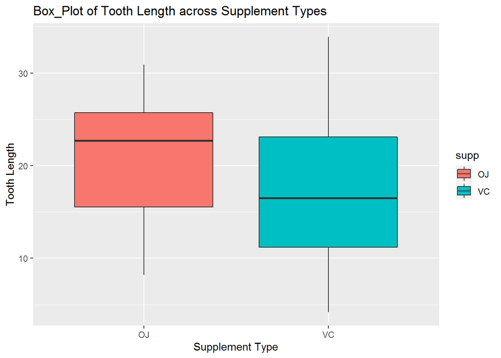

```r
ggplot(aes(x = supp, y = len), data = ToothGrowth) +
        geom_boxplot(aes(fill = supp)) +
        labs(title = "Box_Plot of Tooth Length across Supplement Types",
             x = "Supplement Type", y = "Tooth Length")
```

[figure not shown]

```r
ggplot(aes(x=dose, y = len), data = ToothGrowth) +
     labs(x = "Tooth Length", y = "Dosage Frequency", title = "Tooth Lengths by Dosage and Supplement") +
    geom_point(aes(color = supp))
```

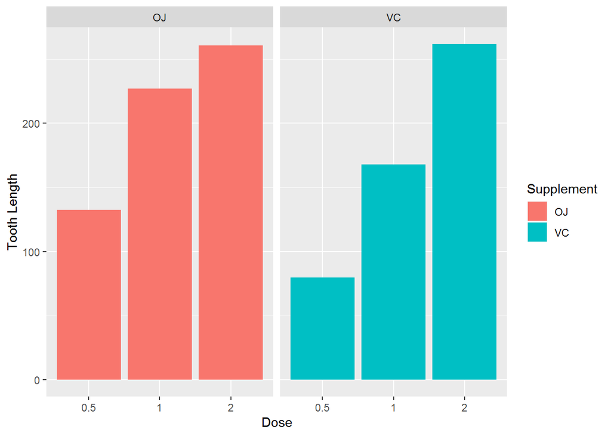

```r
ggplot(data=ToothGrowth, aes(x=as.factor(dose), y=len, fill=supp)) +
    geom_bar(stat="identity") +
    facet_grid(. ~ supp) +
    xlab("Dose") +
    ylab("Tooth Length") +
    guides(fill=guide_legend(title="Supplement"))
```

There appears to be an impact on tooth growth by increasing the dosage but it is unclear which of the two supplements contributes to the growth.

Use confidence intervals and/or hypothesis tests to compare tooth growth by supp and dose

Use t.test to determine if there is a difference in the performance of the treatments. First, we will run the test based on supplement. Looking to see if the p-value > 0.05 and if the confidence interval crosses 0.

```r
t.test(ToothGrowth$len[ToothGrowth$supp=="OJ"], ToothGrowth$len[ToothGrowth$supp=="VC"], paired = FALSE, var.equal = FALSE)
```

```
##
##  Welch Two Sample t-test
##
## data:  ToothGrowth$len[ToothGrowth$supp == "OJ"] and ToothGrowth$len[ToothGrowth$supp == "VC"]
## t = 1.9153, df = 55.309, p-value = 0.06063
## alternative hypothesis: true difference in means is not equal to 0
## 95 percent confidence interval:
##  -0.1710156  7.5710156
## sample estimates:
## mean of x mean of y
##  20.66333  16.96333
```

The p-value is 0.06063 and the confidence interval is [-0.1710156 7.5710156], thus containing 0.

Since the p-value is 0.06063, there is not enough evidence to reject the null hypothesis. We cannot assume the delivery type has a significant effect on tooth growth.

Test the tooth length comparing the dosage of 1mg to 2mg to determine the effects of an increased dosage.

```r
t.test(ToothGrowth$len[ToothGrowth$dose==2], ToothGrowth$len[ToothGrowth$dose==1], paired = FALSE, var.equal = TRUE)
```

```
##
##  Two Sample t-test
##
## data:  ToothGrowth$len[ToothGrowth$dose == 2] and ToothGrowth$len[ToothGrowth$dose == 1]
## t = 4.9005, df = 38, p-value = 1.811e-05
## alternative hypothesis: true difference in means is not equal to 0
## 95 percent confidence interval:
##  3.735613 8.994387
## sample estimates:
## mean of x mean of y
##    26.100    19.735
```

We see the p-value is very small, and is significant. Therefore, we can reject the null hypothesis and assume the dosage increase from 1mg to 2mg creates an positive effect on tooth growth.

Next, perform the test comparing the dosage of 0.5mg to 1mg.

```r
t.test(ToothGrowth$len[ToothGrowth$dose==1], ToothGrowth$len[ToothGrowth$dose==0.5], paired = FALSE, var.equal = TRUE)
```

```
##
##  Two Sample t-test
##
## data:  ToothGrowth$len[ToothGrowth$dose == 1] and ToothGrowth$len[ToothGrowth$dose == 0.5]
## t = 6.4766, df = 38, p-value = 1.266e-07
## alternative hypothesis: true difference in means is not equal to 0
## 95 percent confidence interval:
##   6.276252 11.983748
## sample estimates:
## mean of x mean of y
##    19.735    10.605
```

We can again reject the null hypothesis and assume the dosage increase from .5mg to 1mg creates an positive effect on tooth growth.

There is no need for futher testing of dosages given the previous tests.

## Conclusions and Assumptions

In this experiment, we assume there is a common variance in the population and that the guinea pigs were chosen at random.

The delivery type does not show a significant increase in tooth growth even though it does have a confidence level that crosses 0 at the 95% confidence.

However, there does appear to be a difference with an increase in tooth growth when the dosage is increased. The tests comparing the dosage show confidence intervals of differences never crossing zero.

# Conclusion

Increasing the dosage leads to an increase in tooth growth in guinea pigs.